# Analyzing Impact of Transit-Oriented Development (TOD) in Boston, MA

Jiamin Tan

```r
# packages used
library(tidyverse)
library(tidycensus)
library(sf)
library(gridExtra)
library(grid)
library(knitr)
library(kableExtra)
library(rmarkdown)
library(viridis)
library(scales)
library(patchwork)

# set number notation
options(scipen=999)
```

```r
# codes in this chunk are adopted (and modified) from Ken Steif's book:
# Public Policy Analytics: Code & Context for Data Science in Government
# https://urbanspatial.github.io/PublicPolicyAnalytics/index.html

mapTheme <- function(base_size = 12) {
  theme(
    text = element_text(color = "black"),
    plot.title = element_text(size = 16, colour = "black"),
    plot.subtitle = element_text(face="italic"),
    plot.caption = element_text(hjust=0),
    axis.ticks = element_blank(),
    panel.background = element_blank(),
    axis.title = element_blank(),
    axis.text = element_blank(),
    axis.title.x = element_blank(),
    axis.title.y = element_blank(),
    panel.grid.minor = element_blank(),
    panel.border = element_rect(colour = "black", fill=NA, size=1),
    strip.text.x = element_text(size = 14))
}

plotTheme <- function(base_size = 12) {
  theme(
    text = element_text( color = "black"),
    plot.title = element_text(size = 16, colour = "black"),
    plot.subtitle = element_text(face="italic"),
    plot.caption = element_text(hjust=0),
    axis.ticks = element_blank(),
    panel.background = element_blank(),
    panel.grid.major = element_line("grey90", size = 0.1),
    panel.grid.minor = element_blank(),
    panel.border = element_rect(colour = "black", fill = NA, size = 1),
    strip.background = element_rect(fill = "grey80", color = "grey80", size = 0.5),
    strip.text = element_text(size = 12),
    axis.title = element_text(size = 12),
    axis.text = element_text(size = 10),
    plot.background = element_blank(),
    legend.background = element_blank(),
    legend.title = element_text(colour = "black", face = "italic"),
    legend.text = element_text(colour = "black", face = "italic"),
    strip.text.x = element_text(size = 14)
  )
}

qBr <- function(df, variable, rnd) {
  if (missing(rnd)) {
    tmp <- data.frame(round(quantile(na.omit(df[[variable]]), c(.00, .20, .40, .60, .80))))
    paste(tmp[,1], " (", str_replace(row.names(tmp), "%", "th percentile"), ")", sep = "")
  } else if (rnd == FALSE | rnd == F) {
    tmp <- data.frame(round(quantile(na.omit(df[[variable]])*100, c(.00, .20, .40, .60, .80)), digits = 2))
    paste(tmp[,1], "% (", str_replace(row.names(tmp), "%", "th percentile"), ")", sep = "")
  }
}

q5 <- function(variable) {as.factor(ntile(variable, 5))}
```

## 1. Introduction

In 2017, the City of Boston published its first citywide plan in fifty years - [*Imagine Boston 2030: A Plan for the Future of Boston*](https://www.boston.gov/sites/default/files/embed/file/2018-06/imagine20boston202030_pages2.pdf). The plan proposed to enhance its neighborhoods so that the city can retain the young professionals educated and trained in Boston. One of strategies proposed was to make better connection between neighborhoods and the transit system. Specifically, transit-oriented development (TOD) was mentioned in multiple neighborhood plans and corridor plans. This study focuses on the impact of potential TODs around MBTA Rapid Transit stations between 2010 and 2017 and explores whether TODs have successfully retained young professionals as wished by the city. It also explores other demographic and socioeconomic conditions in TOD areas. This study concludes that TOD neighborhoods are more attractive to young professionals than non-TOD neighborhoods are, while the TOD neighborhoods might have gentrification problems which need more attention from the city.

## 2. Data

This section documents raw data used for this study and where they are retrieved.

### 2.1 Census Data and Interested Variables

First, census tracts within the City of Boston are used as the smallest geographic units for analysis. Demographic and socioeconomic data of each census tract are pulled from the 2006-2010 5-year American Community Survey (ACS) and the 2013-2017 5-year ACS published by the US Census Bureau.

Since this study focuses on whether TODs can effectively attract and retain young professionals in Boston, variables related to demography and housing are selected. Specifically, these variables include: total population, median age, population between 18 and 34 years old with bachelor’s degrees, median family income, median rent, and percentage of income spent on rent. Table 1 below shows the raw variables retrieved from the census data. A percentage of young professionals is then derived by calculating the ratio of population between 18 and 34 years old with bachelor’s degrees in total population.

```r
# variables used for this analysis
vars_used <- c("B01003_001",  # Total Population
               "B25064_001",  # Median Gross Rent in Dollars
               "B19113_001",  # Median Family Income in the Past 12 Months
               "B25071_001",  # Median gross rent as a percentage of household income
               "B01002_001",  # Median Age
               "B15001_009",  # Bachelor's Degree, 18-24 Male
               "B15001_017",  # Bachelor's Degree, 25-34 Male
               "B15001_050",  # Bachelor's Degree, 18-24 Female
               "B15001_058")  # Bachelor's Degree, 25-34 Female

# create a table showing all the variables used and their descriptions
vars_table <- var_10_acs5 %>% dplyr::filter(name %in% vars_used)

# print out the table
knitr::kable(vars_table,
             col.names = tools::toTitleCase(names(vars_table)),
             caption = "Table 1: Census Variables Used in This Study (source: 2010 ACS 5-year estimate, US Census Bureau)") %>%
  kable_styling("striped")
```

Table 1: Census Variables Used in This Study (source: 2010 ACS 5-year estimate, US Census Bureau)

| Name | Label | Concept |
| --- | --- | --- |
| B01002_001 | Estimate!!Median age!!Total | MEDIAN AGE BY SEX |
| B01003_001 | Estimate!!Total | TOTAL POPULATION |
| B15001_009 | Estimate!!Total!!Male!!18 to 24 years!!Bachelor’s degree | SEX BY AGE BY EDUCATIONAL ATTAINMENT FOR THE POPULATION 18 YEARS AND OVER |
| B15001_017 | Estimate!!Total!!Male!!25 to 34 years!!Bachelor’s degree | SEX BY AGE BY EDUCATIONAL ATTAINMENT FOR THE POPULATION 18 YEARS AND OVER |
| B15001_050 | Estimate!!Total!!Female!!18 to 24 years!!Bachelor’s degree | SEX BY AGE BY EDUCATIONAL ATTAINMENT FOR THE POPULATION 18 YEARS AND OVER |
| B15001_058 | Estimate!!Total!!Female!!25 to 34 years!!Bachelor’s degree | SEX BY AGE BY EDUCATIONAL ATTAINMENT FOR THE POPULATION 18 YEARS AND OVER |
| B19113_001 | Estimate!!Median family income in the past 12 months (in 2010 inflation-adjusted dollars) | MEDIAN FAMILY INCOME IN THE PAST 12 MONTHS (IN 2010 INFLATION-ADJUSTED DOLLARS) |
| B25064_001 | Estimate!!Median gross rent | MEDIAN GROSS RENT (DOLLARS) |
| B25071_001 | Estimate!!Median gross rent as a percentage of household income | MEDIAN GROSS RENT AS A PERCENTAGE OF HOUSEHOLD INCOME IN THE PAST 12 MONTHS (DOLLARS) |

```r
# get the 2010 census tract data of Suffolk County
dat_10_acs5 <- get_acs(geography = "tract",
                       state = 25, # MA
                       county = 025, # Suffolk County
                       variables = vars_used,
                       year = 2010,
                       survey = "acs5",
                       geometry = TRUE,
                       output = "wide") %>%
  st_transform('ESRI:102686') %>% ## 102686
  rename(TotalPop = B01003_001E,
         MedRent = B25064_001E,
         MedIncome = B19113_001E,
         pctRent = B25071_001E,
         MedAge = B01002_001E,
         M18Bachelor = B15001_009E,
         M25Bachelor = B15001_017E,
         F18Bachelor = B15001_050E,
         F25Bachelor = B15001_058E) %>%
  dplyr::select(-NAME, -starts_with("B")) %>%
  dplyr::mutate(year = 2010)

# get the 2017 census tract data of Suffolk County
dat_17_acs5 <- get_acs(geography = "tract",
                       state = 25, # MA
                       county = 025, # Suffolk County
                       variables = vars_used,
                       year = 2017,
                       survey = "acs5",
                       geometry = TRUE,
                       output = "wide") %>%
  st_transform('ESRI:102686') %>%
  rename(TotalPop = B01003_001E,
         MedRent = B25064_001E,
         MedIncome = B19113_001E,
         pctRent = B25071_001E,
         MedAge = B01002_001E,
         M18Bachelor = B15001_009E,
         M25Bachelor = B15001_017E,
         F18Bachelor = B15001_050E,
         F25Bachelor = B15001_058E) %>%
  dplyr::select(-NAME, -starts_with("B")) %>%
  dplyr::mutate(year = 2017)
```

```r
# create pct variables of 2010
dat_10_acs5 <-
  dat_10_acs5 %>%
  mutate(pctYoungBach = ifelse(TotalPop > 0,
                               ((M18Bachelor + M25Bachelor + F18Bachelor + F25Bachelor) / TotalPop),
                               0),
         pctRent = pctRent/100,
         year = "2010") %>%
  dplyr::select(-M18Bachelor, -F18Bachelor, -M25Bachelor, -F25Bachelor)

# create pct variables of 2017
dat_17_acs5 <-
  dat_17_acs5 %>%
  mutate(pctYoungBach = ifelse(TotalPop > 0,
                               ((M18Bachelor + M25Bachelor + F18Bachelor + F25Bachelor) / TotalPop),
                               0),
         pctRent = pctRent/100,
         year = "2017") %>%
  dplyr::select(-M18Bachelor, -F18Bachelor, -M25Bachelor, -F25Bachelor)
```

### 2.2 MBTA Rapid Transit Stations

```r
# MBTA rapid transit GIS data sources
# https://www.mass.gov/info-details/massgis-data-mbta-rapid-transit

# importing MBTA rapid transit stops
MBTA_Stops <- st_read("mbta_rapid_transit/MBTA_NODE.shp") %>%
  st_transform(st_crs(dat_17_acs5))

# importing MBTA rapid transit arcs
MBTA_Arcs <- st_read("mbta_rapid_transit/MBTA_ARC.shp") %>%
  st_transform(st_crs(dat_17_acs5))

# Boston city boundary
# data source: https://data.boston.gov/dataset/city-of-boston-boundary/resource/53e1ef88-950e-4b91-8b2a-f05f2e025f69?inner_span=True
Boston_Boundary <- st_read("City_of_Boston_Boundary.shp") %>%
  st_transform(st_crs(dat_17_acs5))

# make the boundary a valid polygon
Boston_Boundary <- st_make_valid(Boston_Boundary)

# identify MBTA stations within Boston
MBTA_Stops <- st_intersection(MBTA_Stops, Boston_Boundary) %>%
  dplyr::select(everything())

# identify census tracts within Boston
dat_10_acs5 <- dat_10_acs5[Boston_Boundary, ]
dat_17_acs5 <- dat_17_acs5[Boston_Boundary, ]

# combine all data from two years
allTracts <- rbind(dat_10_acs5, dat_17_acs5)

# identify transfer stations for mapping purpose
for (i in 1:nrow(MBTA_Stops)){
  MBTA_Stops$UNQLINE[i] = ifelse(grepl("/", MBTA_Stops$LINE[i]), "TRANSFER", MBTA_Stops$LINE[i])
}
```

Second, transit data used in this study only consider MBTA Rapid Transit stations within the City of Boston. That means only stations on MBTA’s blue line, green line and its branches, orange line, red line, and silver line and its branches are targeted for analysis. Bus stops are not considered because they usually generate much smaller effects on built environment nearby. Rapid transit stations outside the city’s administrative boundary are not considered either because they fall in different municipalities which might have different housing policies from the City of Boston. MBTA Rapid Transit data are downloaded from this [MassGIS Data](https://www.mass.gov/info-details/massgis-data-mbta-rapid-transit) web page. Figure 1 below shows all rapid transit stations considered in this study.

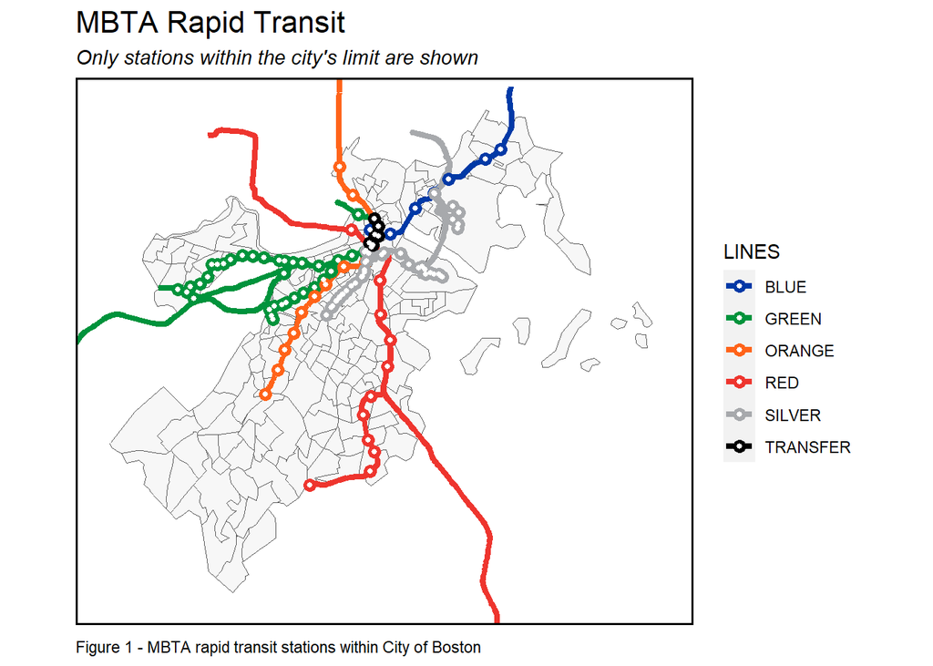

```r
# plot all stops by their line color
ggplot() +
  geom_sf(data = dat_17_acs5, fill = "#f7f7f7", lwd = 0.3) +
  geom_sf(data = MBTA_Arcs, aes(colour = LINE), lwd = 1.5, show.legend = "line", size = 1) +
    scale_color_manual(values = c("#0039A6",      # blue
                                  "#00933C",      # green
                                  "#FF6319",      # orange
                                  "#EE352E",      # red
                                  "#A7A9AC")) +   # silver
  geom_sf(data = MBTA_Stops, aes(colour = UNQLINE), lwd = 3, show.legend = "point", size = 1) +
    scale_color_manual(values = c("#0039A6",      # blue
                                  "#00933C",      # green
                                  "#FF6319",      # orange
                                  "#EE352E",      # red
                                  "#A7A9AC",      # silver
                                  "black")) +     # transfer station with 2 or more lines
  geom_sf(data = MBTA_Stops, color = "white", lwd = 1, show.legend = "point", size = 1) +
  coord_sf(xlim = c(738970, 813975), ylim = c(2907400, 2973900), crs = st_crs(dat_17_acs5)) +
  labs(title = "MBTA Rapid Transit",
       subtitle = "Only stations within the city's limit are shown",
       caption = "Figure 1 - MBTA rapid transit stations within City of Boston") +
  guides(color=guide_legend("LINES")) +
  mapTheme()
```

## 3. Methods

To identify areas influenced by TODs, a buffer with a 0.5-mile radius is created from each station. The dashed red line in Figure 2 shows the range of the buffer. Despite that the [smart growth / smart energy toolkit](https://www.mass.gov/service-details/smart-growth-smart-energy-toolkit-modules-transit-oriented-development-tod#:~:text=TOD%20occurs%20within%20one%2Dquarter,Copley%20Place%20in%20Boston) provided by the MA government suggests TODs often occurs within 0.25 mile from a transit station, this study uses the 0.5-mile buffer because the shape of a census tract is irregular and a 0.25-mile buffer less effectively captures all census tracts which could be potentially impacted by TODs.

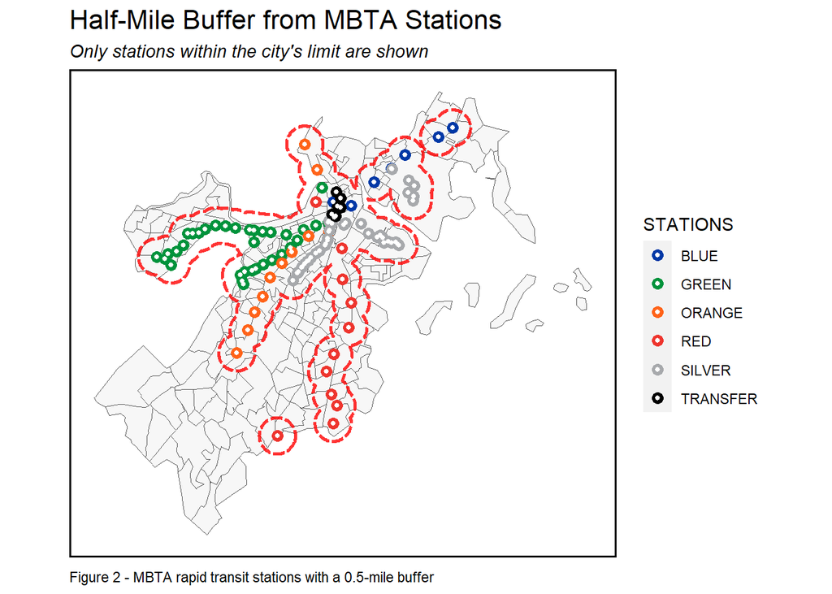

```r
# buffer all the stops with a radius of 1/2 mile (2640 ft)
Stops_Buffers <-
  rbind(
    st_buffer(MBTA_Stops, 2640) %>%
      mutate(Legend = "Buffer") %>%
      dplyr::select(Legend),
    # dissolve all the individual buffers
    st_union(st_buffer(MBTA_Stops, 2640)) %>%
      st_sf() %>%
      mutate(Legend = "Unioned Buffer"))

# Create an sf object with ONLY the unioned buffer
buffer <- filter(Stops_Buffers, Legend == "Unioned Buffer")

# visualization of buffers
ggplot() +
  geom_sf(data = dat_17_acs5, fill = "#f7f7f7", lwd = 0.3) +
  geom_sf(data = MBTA_Stops, aes(colour = UNQLINE), lwd = 3, show.legend = "point", size = 1) +
  scale_color_manual(values = c("#0039A6",      # blue
                                "#00933C",      # green
                                "#FF6319",      # orange
                                "#EE352E",      # red
                                "#A7A9AC",      # silver
                                "black")) +
  geom_sf(data = MBTA_Stops, color = "white", lwd = 1, show.legend = "point", size = 1) +
  geom_sf(data = buffer, fill = NA, lwd = 1, color = alpha("red", 0.8), linetype = "41") +
  labs(title = "Half-Mile Buffer from MBTA Stations",
       subtitle = "Only stations within the city's limit are shown",
       caption = "Figure 2 - MBTA rapid transit stations with a 0.5-mile buffer") +
  guides(color=guide_legend("STATIONS")) +
  mapTheme()
```

To remedy the condition of using a oversize buffer, a stricter selection of census tracts is introduced. Figure 3a and 3b demostrate two different methods of census tracts selection. In Figure 3a, a census tract is identified as impacted by TODs as long as any part of it is touched by the 0.5-mile buffer. In Figure 3b, however, a census tract is identified as impacted by TODs only if its center point (centroid) is covered within the 0.5-mile. Using the selection method in Figure 3b, the selection ensures all the census tracts which are indeed influenced by TODs are selected while avoids census tracts which are too far away from stations to be selected.

```r
# Do a spatial selection to see which tracts touch the buffer
touched_tracts10 <-
  dat_10_acs5[buffer,] %>%
  dplyr::select(everything()) %>%
  mutate(Selection_Type = "Spatial Selection")

touched_tracts17 <-
  dat_17_acs5[buffer,] %>%
  dplyr::select(everything()) %>%
  mutate(Selection_Type = "Spatial Selection")

# select tracts if the centroid is covered
selectCentroids10 <-
  st_centroid(dat_10_acs5)[buffer,] %>%
  st_drop_geometry() %>%
  left_join(dplyr::select(dat_10_acs5, GEOID)) %>%
  st_sf() %>%
  dplyr::select(everything()) %>%
  mutate(Selection_Type = "Select by Centroids")

selectCentroids17 <-
  st_centroid(dat_17_acs5)[buffer,] %>%
  st_drop_geometry() %>%
  left_join(dplyr::select(dat_17_acs5, GEOID)) %>%
  st_sf() %>%
  dplyr::select(everything()) %>%
  mutate(Selection_Type = "Select by Centroids")
```

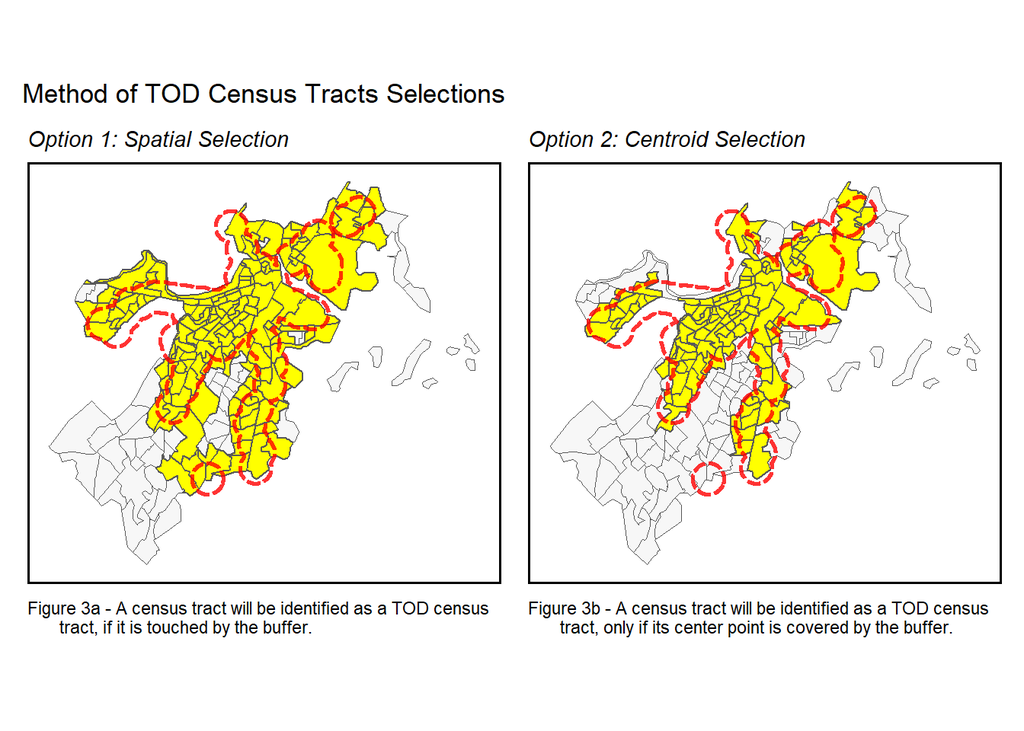

```r
# spatial selection
touched <- ggplot() +
  geom_sf(data = dat_17_acs5, fill = "#f7f7f7", lwd = 0.3) +
  geom_sf(data = touched_tracts17, fill = "#FFFF00", lwd = 0.5) +
  geom_sf(data = buffer, fill = NA, lwd = 1, color = alpha("red", 0.8), linetype = "41") +
  labs(subtitle = "Option 1: Spatial Selection",
       caption = "Figure 3a - A census tract will be identified as a TOD census
       tract, if it is touched by the buffer.") +
  mapTheme()

# centroid selection
centroid <- ggplot() +
  geom_sf(data = dat_17_acs5, fill = "#f7f7f7", lwd = 0.3) +
  geom_sf(data = selectCentroids17, fill = "#FFFF00", lwd = 0.5) +
  geom_sf(data = buffer, fill = NA, lwd = 1, color = alpha("red", 0.8), linetype = "41") +
  labs(subtitle = "Option 2: Centroid Selection",
       caption = "Figure 3b - A census tract will be identified as a TOD census
       tract, only if its center point is covered by the buffer.") +
  mapTheme()

# selection results plotted in a row
touched + centroid + plot_annotation(title = "Method of TOD Census Tracts Selections")
```

The analysis in this study only considers census tracts selected in Figure 3b. In addition, to unify the monetary measure between 2010 and 2017, the monetary data in 2010 is multiplied by a inflation coefficient of 1.12 so that all the values are in 2017 dollars. The inflation coefficient is determined using the [US Inflation Calculator](https://www.usinflationcalculator.com/).

```r
# centroid selection with census tracts from both years
allTracts.group <-
  rbind(
    st_centroid(allTracts)[buffer,] %>%
      st_drop_geometry() %>%
      left_join(allTracts) %>%
      st_sf() %>%
      mutate(TOD = "TOD"),
    st_centroid(allTracts)[buffer, op = st_disjoint] %>%
      st_drop_geometry() %>%
      left_join(allTracts) %>%
      st_sf() %>%
      mutate(TOD = "Non-TOD")) %>%
  # convert all monetary variables into 2017 dollars
  # inflation coef: https://www.usinflationcalculator.com/
  mutate(MedRent.inf = ifelse(year == "2010",
                              MedRent * 1.12,
                              ## consider inflation
                              MedRent)) %>%
  mutate(MedIncome.inf = ifelse(year == "2010",
                                MedIncome * 1.12,
                                ## consider inflation
                                MedIncome))
```

## 4. Exploratory Choropleth Mappping

This section visualizes each census variables mentioned above by choropleth mapping which helps to understand spatial patterns of demographic and socioeconomic variables.

### 4.1 Total Population

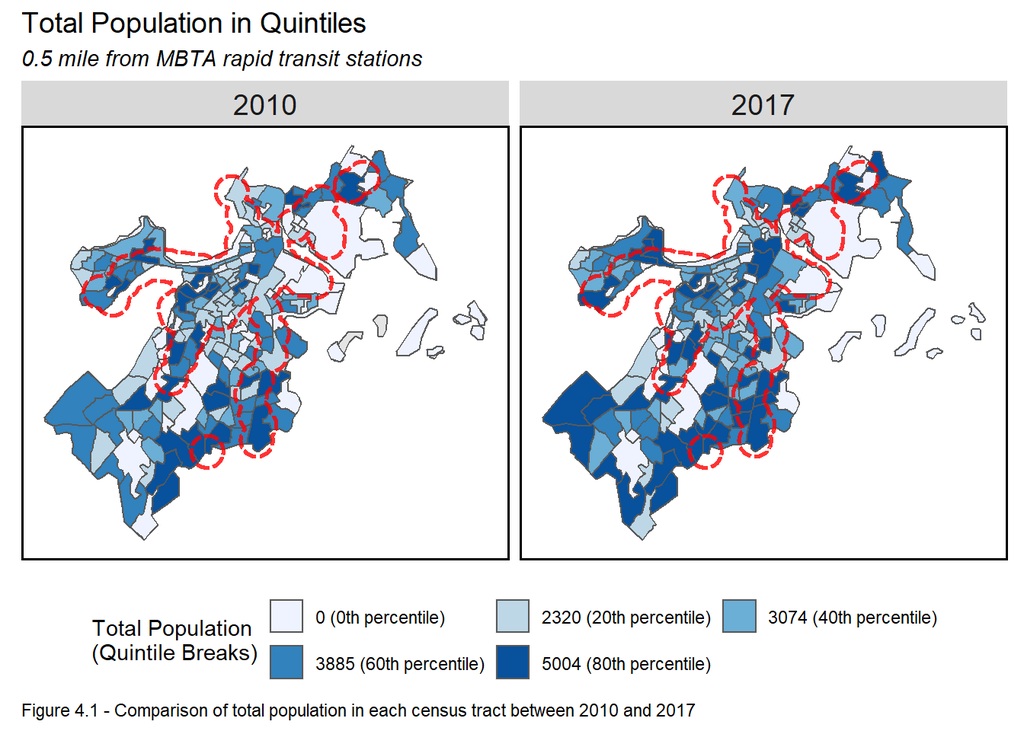

```r
# total pop
ggplot(allTracts.group)+
  geom_sf(data = st_union(dat_17_acs5))+
  geom_sf(aes(fill = q5(TotalPop))) +
    scale_fill_manual(values = alpha(brewer_pal(palette = "Blues")(5), 1),
                    labels = qBr(allTracts.group, "TotalPop"),
                    name = "Total Population\n(Quintile Breaks)") +
  geom_sf(data = buffer, fill = NA, lwd = 1, color = alpha("red", 0.8), linetype = "41") +
  labs(title = "Total Population in Quintiles",
       subtitle = "0.5 mile from MBTA rapid transit stations",
       caption = "Figure 4.1 - Comparison of total population in each census tract between 2010 and 2017") +
  facet_wrap(~year) +
  mapTheme() +
  theme(plot.title = element_text(size=14), legend.position = "bottom") +
  guides(fill = guide_legend(nrow = 2, byrow = TRUE))
```

The total population in Boston increased between 2010 and 2017, and such increase spread out in the city. However, it is hard to tell whether TOD census tracts have greater population increase than non-TOD census tracts do, purely based on the two maps in Figure 4.1. Further analysis on population changes is carried out in Section 5 below, and it concludes non-TOD census tracts had greater population increase than TOD census tract did between 2010 and 2017.

### 4.2 Median Age

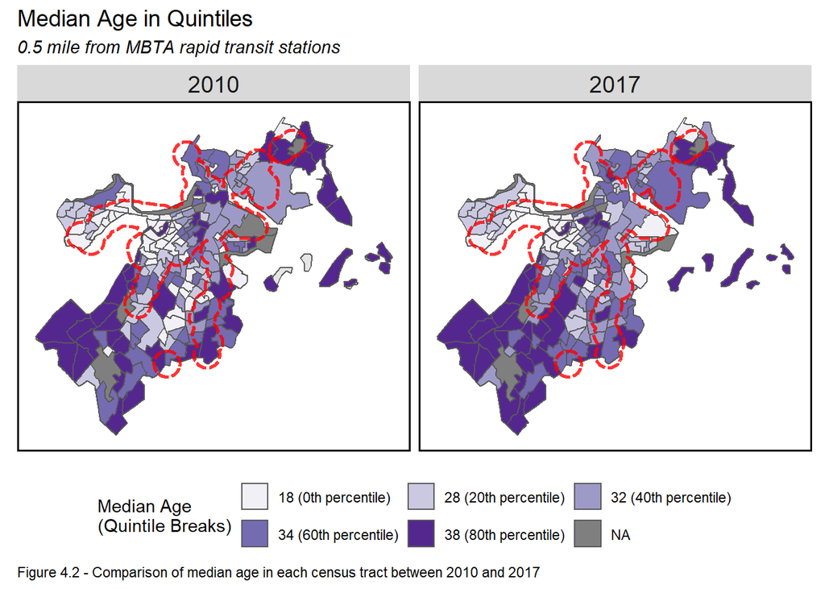

```r
# MedAge
ggplot(allTracts.group)+
  geom_sf(data = st_union(dat_17_acs5))+
  geom_sf(aes(fill = q5(MedAge))) +
    scale_fill_manual(values = alpha(brewer_pal(palette = "Purples")(5), 1),
                      labels = qBr(allTracts.group, "MedAge"),
                      name = "Median Age\n(Quintile Breaks)") +
  geom_sf(data = buffer, fill = NA, lwd = 1, color = alpha("red", 0.8), linetype = "41") +
  labs(title = "Median Age in Quintiles",
       subtitle = "0.5 mile from MBTA rapid transit stations",
       caption = "Figure 4.2 - Comparison of median age in each census tract between 2010 and 2017") +
  facet_wrap(~year) +
  mapTheme() +
  theme(plot.title = element_text(size=14), legend.position = "bottom") +
  guides(fill = guide_legend(nrow = 2, byrow = TRUE))
```

TODs attract younger population. In Figure 4.2, a clear spatial distribution of median age can be observed. In both years, census tracts located in the southern part of the city have greater median age than do those located in central or northern parts of the city. Areas that has the youngest population are those near Boston University and Northeastern University. When comparing median age of TOD areas with median age of non-TOD areas, contrasts between younger population and older population at two sides of the TOD buffer can be easily observed in the central part of the city, especially at stations along the Orange Line. Therefore, as the total population increased in Boston, younger population were attracted to live in TOD areas between 2010 and 2017.

### 4.3 Young Profssionals

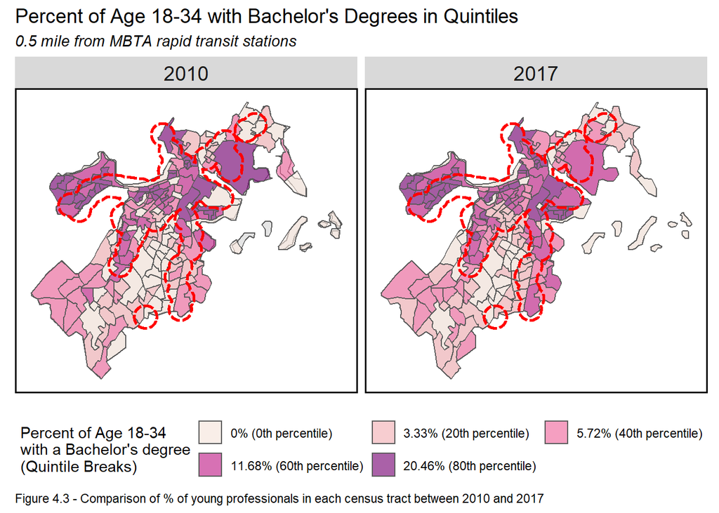

```r
# pctYoungBach
ggplot(allTracts.group)+
  geom_sf(data = st_union(dat_17_acs5))+
  geom_sf(aes(fill = q5(pctYoungBach))) +
    scale_fill_manual(values = alpha(brewer_pal(palette = "RdPu")(5), 0.6),
                      labels = qBr(allTracts.group, "pctYoungBach", rnd = FALSE),
                      name = "Percent of Age 18-34\nwith a Bachelor's degree\n(Quintile Breaks)") +
  geom_sf(data = buffer, fill = NA, lwd = 1, color = alpha("red", 1), linetype = "41") +
  labs(title = "Percent of Age 18-34 with Bachelor's Degrees in Quintiles",
       subtitle = "0.5 mile from MBTA rapid transit stations",
       caption = "Figure 4.3 - Comparison of % of young professionals in each census tract between 2010 and 2017") +
  facet_wrap(~year) +
  mapTheme() +
  theme(plot.title = element_text(size=14), legend.position = "bottom") +
  guides(fill = guide_legend(nrow = 2, byrow = TRUE))
```

TODs areas are potentially more attractive to young professionals than non-TODs areas are. As expected, areas near big universities have the highest concentration of young professionals. In Figure 4.3, another hot spot of young professionals is the downtown area where mixed used developments are encouraged. So far, it is hard to tell whether young professionals are attracted by the locations themselves, universities and downtown, or by TODs. However, the maps also show a clear increase of young professionals’ population along the Red Line from 2010 to 2017. Therefore, before running specific numbers in section 5, one can expect that TODs areas are more attractive to young professionals living in Boston.

### 4.4 Median Family Income

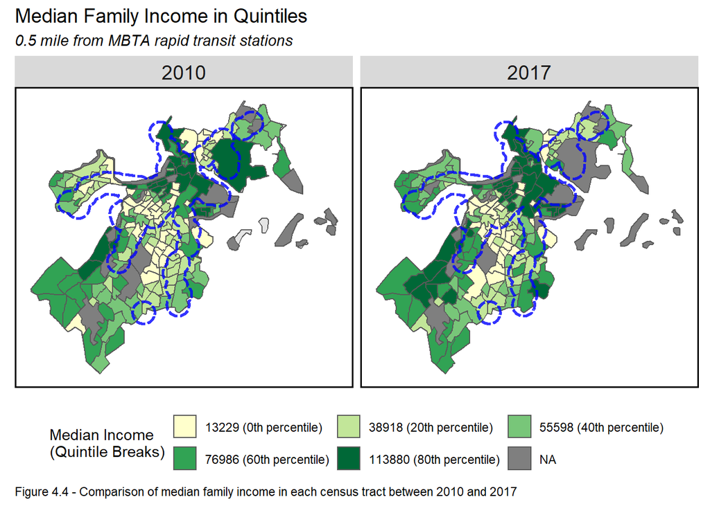

```r
# median income
ggplot(allTracts.group)+
  geom_sf(data = st_union(dat_17_acs5))+
  geom_sf(aes(fill = q5(MedIncome))) +
    scale_fill_manual(values = alpha(brewer_pal(palette = "YlGn")(5), 1),
                      labels = qBr(allTracts.group, "MedIncome"),
                      name = "Median Income\n(Quintile Breaks)") +
  geom_sf(data = buffer, fill = NA, lwd = 1, color = alpha("blue", 0.8), linetype = "41") +
  labs(title = "Median Family Income in Quintiles",
       subtitle = "0.5 mile from MBTA rapid transit stations",
       caption = "Figure 4.4 - Comparison of median family income in each census tract between 2010 and 2017") +
  facet_wrap(~year) +
  mapTheme() +
  theme(plot.title = element_text(size=14), legend.position = "bottom") +
  guides(fill = guide_legend(nrow = 2, byrow = TRUE))
```

TOD areas do not necessarily indicate higher family income. In Figure 4.4, no obvious changes in median family income between 2010 and 2017 is found. In addition, there are mixtures of high income and low income areas in both TOD census tracts and non-TOD census tracts. Although Section 5 below will provide the precise number of average family median income in both types of areas, it is unclear whether it was the TODs boost the local income or it was the TODs attract families with higher income to move into the region.

### 4.5 Median Rent

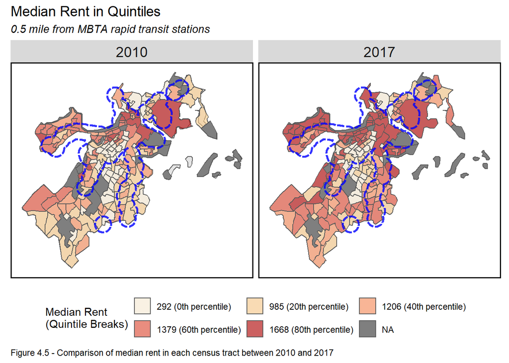

```r
# MedRent
ggplot(allTracts.group)+
  geom_sf(data = st_union(dat_17_acs5))+
  geom_sf(aes(fill = q5(MedRent))) +
    scale_fill_manual(values = alpha(brewer_pal(palette = "OrRd")(5), 0.6),
                      labels = qBr(allTracts.group, "MedRent"),
                      name = "Median Rent\n(Quintile Breaks)") +
  geom_sf(data = buffer, fill = NA, lwd = 1, color = alpha("blue", 0.8), linetype = "41") +
  labs(title = "Median Rent in Quintiles",
       subtitle = "0.5 mile from MBTA rapid transit stations",
       caption = "Figure 4.5 - Comparison of median rent in each census tract between 2010 and 2017") +
  facet_wrap(~year) +
  mapTheme() +
  theme(plot.title = element_text(size=14), legend.position = "bottom") +
  guides(fill = guide_legend(nrow = 2, byrow = TRUE))
```

The median rent increased in most part of the city, regardless whether TODs took place. Figure 4.5 shows that, except in the central area where the median rent percentile did not change much, rent in other parts of the city went up between 2010 and 2017. Since the central part is only partially aligned within the TOD census tracts, the relationship between TODs and rent need to further discussed in Section 5.

### 4.6 Percent of Income Spent on Rent

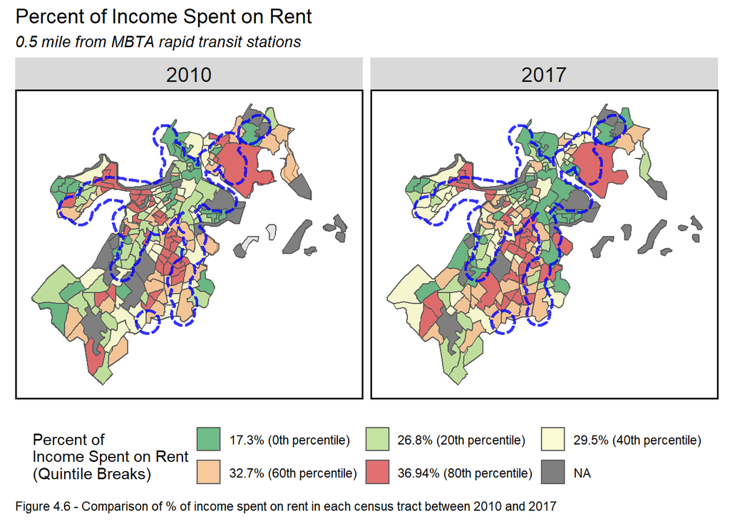

```r
# pctRent
ggplot(allTracts.group)+
  geom_sf(data = st_union(dat_17_acs5))+
  geom_sf(aes(fill = q5(pctRent))) +
    scale_fill_manual(values = alpha(brewer_pal(palette = "RdYlGn", direction = -1)(5), 0.6),
                      labels = qBr(allTracts.group, "pctRent", rnd = FALSE),
                      name = "Percent of\nIncome Spent on Rent\n(Quintile Breaks)") +
  geom_sf(data = buffer, fill = NA, lwd = 1, color = alpha("blue", 0.8), linetype = "41") +
  labs(title = "Percent of Income Spent on Rent",
       subtitle = "0.5 mile from MBTA rapid transit stations",
       caption = "Figure 4.6 - Comparison of % of income spent on rent in each census tract between 2010 and 2017") +
  facet_wrap(~year) +
  mapTheme() +
  theme(plot.title = element_text(size=14), legend.position = "bottom") +
  guides(fill = guide_legend(nrow = 2, byrow = TRUE))
```

The rent burden was exacerbated in non-TOD areas. In Figure 4.6, TOD census tracts along the Green Line in the western part of the city have lower ratio of income spent on rent in 2017 compare to 2010. However, census tracts in the non-TOD area between the Orange Line and the Red Line in the central part of the city are ranked with higher percentile with high ratio of income spent on rent in 2017. Moreover, non-TOD census tracts in the southwest also have greater portion of income spent on rent in 2017.

## 5. Analysis and Discussion

This section further explores patterns discovered in Section 4 using specific data across time and space.

### 5.1 TOD area vs Non-TOD area

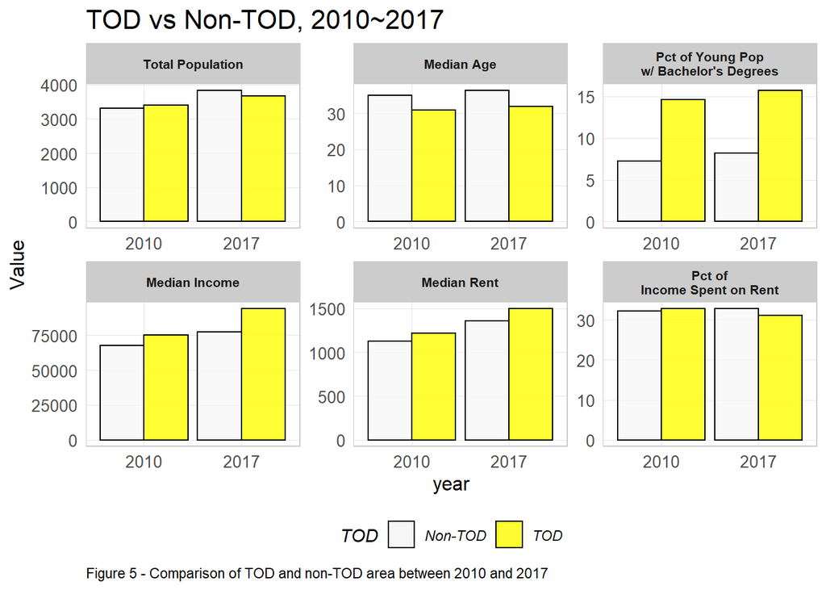

```r
# summerise all the information for plotting
allTracts.Summary <-
  st_drop_geometry(allTracts.group) %>%
  group_by(year, TOD) %>%
  summarize(Total_Population = round(mean(TotalPop, na.rm = T), 0),
            Median_Age = mean(MedAge, na.rm = T),
            pct_Young_Bach = mean(pctYoungBach, na.rm = T)*100,
            Median_Income = mean(MedIncome, na.rm = T),
            Median_Rent = mean(MedRent, na.rm = T),
            pct_Rent = mean(pctRent, na.rm = T)*100)

labels <- c(Total_Population = "Total Population",
            Median_Age = "Median Age",
            pct_Young_Bach = "Pct of Young Pop\nw/ Bachelor's Degrees",
            Median_Income = "Median Income",
            Median_Rent = "Median Rent",
            pct_Rent = "Pct of\nIncome Spent on Rent")

# transform year to factors
allTracts.Summary$year <- factor(allTracts.Summary$year)

# plot
allTracts.Summary %>%
  gather(Variable, Value, -year, -TOD) %>%
  mutate(Variable = factor(Variable, levels = c("Total_Population", "Median_Age", "pct_Young_Bach",
                                                "Median_Income", "Median_Rent", "pct_Rent"))) %>%
  ggplot(aes(year, Value, fill = TOD)) +
  geom_bar(stat = "identity", position = "dodge", color = "black") +
  facet_wrap(.~Variable, scales = "free", ncol=3, labeller=labeller(Variable = labels)) +
  scale_fill_manual(values = alpha(c("#f7f7f7", "yellow"), 0.8)) +
  labs(title = "TOD vs Non-TOD, 2010~2017 ",
       caption = "Figure 5 - Comparison of TOD and non-TOD area between 2010 and 2017") +
  plotTheme() + theme(legend.position="bottom", strip.text.x = element_text(size = 8, face = "bold"),panel.border = element_rect(colour = "grey80", fill=NA, size=0.5))
```

```r
# create a table showing specific numbers
allTracts.Summary %>%
  unite(year.TOD, year, TOD, sep = ": ", remove = TRUE) %>%
  gather(Variable, Value, -year.TOD) %>%
  mutate(Variable = factor(Variable, levels = c("Total_Population", "Median_Age", "pct_Young_Bach",
                                                "Median_Income", "Median_Rent", "pct_Rent"))) %>%
  mutate(Value = round(Value, 2)) %>%
  spread(year.TOD, Value) %>%
  mutate(Variable = labels) %>%
  kable(caption = "Table 2: Comparison of TOD and non-TOD area between 2010 and 2017") %>%
  kable_styling('striped')
```

Table 2: Comparison of TOD and non-TOD area between 2010 and 2017

| Variable | 2010: Non-TOD | 2010: TOD | 2017: Non-TOD | 2017: TOD |
| --- | --- | --- | --- | --- |
| Total Population | 3319.00 | 3402.00 | 3836.00 | 3667.00 |
| Median Age | 34.94 | 30.79 | 36.34 | 31.85 |
| Pct of Young Pop w/ Bachelor’s Degrees | 7.24 | 14.60 | 8.25 | 15.74 |
| Median Income | 67539.82 | 75172.57 | 77168.41 | 94073.59 |
| Median Rent | 1130.41 | 1217.50 | 1362.18 | 1499.42 |
| Pct of Income Spent on Rent | 32.23 | 32.79 | 32.83 | 31.08 |

Figure 5 and Table 2 above are generated using the average value of each variable in TOD and non-TOD census tracts defined in Section 3, and comparisons of the same variable between 2010 and 2017 are visualized using bar charts. Below are the discussion of how each selected variable performs across space and time.

### 5.2 Changes of Population Covered by Each Station between 2010 and 2017

```r
# 2010
# get the total population for each stop
Stop_Pop10 <- matrix(nrow = nrow(MBTA_Stops), ncol = 1)

for (i in 1:nrow(MBTA_Stops)){
  tmp <- st_centroid(dat_10_acs5)[Stops_Buffers[i, ],] %>%
    st_drop_geometry() %>%
    left_join(dplyr::select(dat_10_acs5, GEOID)) %>%
    dplyr::select(TotalPop)
  ifelse(nrow(tmp) > 0,
         Stop_Pop10[i, ] <- sum(tmp$TotalPop),
         Stop_Pop10[i, ] <- 0)
}
MBTA_Stops_pop <- data.frame(cbind(Stop_Pop10, MBTA_Stops$geometry))
colnames(MBTA_Stops_pop) <- c("pop10", "geometry")
MBTA_Stops_pop <- MBTA_Stops_pop %>% st_as_sf() %>% st_set_crs(st_crs(MBTA_Stops))
MBTA_Stops_pop$pop10 <- unlist(MBTA_Stops_pop$pop10)

# 2017
# get the total population for each stop
Stop_Pop17 <- matrix(nrow = nrow(MBTA_Stops), ncol = 1)
for (i in 1:nrow(MBTA_Stops)){
  tmp<- st_centroid(dat_17_acs5)[Stops_Buffers[i, ],] %>%
    st_drop_geometry() %>%
    left_join(dplyr::select(dat_17_acs5, GEOID)) %>%
    dplyr::select(TotalPop)
  ifelse(nrow(tmp) > 0,
         Stop_Pop17[i, ] <- sum(tmp$TotalPop),
         Stop_Pop17[i, ] <- 0)
}
MBTA_Stops_pop <- data.frame(cbind(Stop_Pop17, MBTA_Stops_pop, MBTA_Stops$STATION, MBTA_Stops$LINE))
colnames(MBTA_Stops_pop) <- c("pop17", "pop10", "STATION", "LINE", "geometry")
MBTA_Stops_pop <- MBTA_Stops_pop %>% st_as_sf() %>% st_set_crs(st_crs(MBTA_Stops))
MBTA_Stops_pop$pop17 <- unlist(MBTA_Stops_pop$pop17)

MBTA_Stops_pop$pop_change <- MBTA_Stops_pop$pop17 - MBTA_Stops_pop$pop10
MBTA_Stops_pop_inc <- MBTA_Stops_pop %>% filter(pop_change>= 0)
MBTA_Stops_pop_dec <- MBTA_Stops_pop %>% filter(pop_change< 0)
```

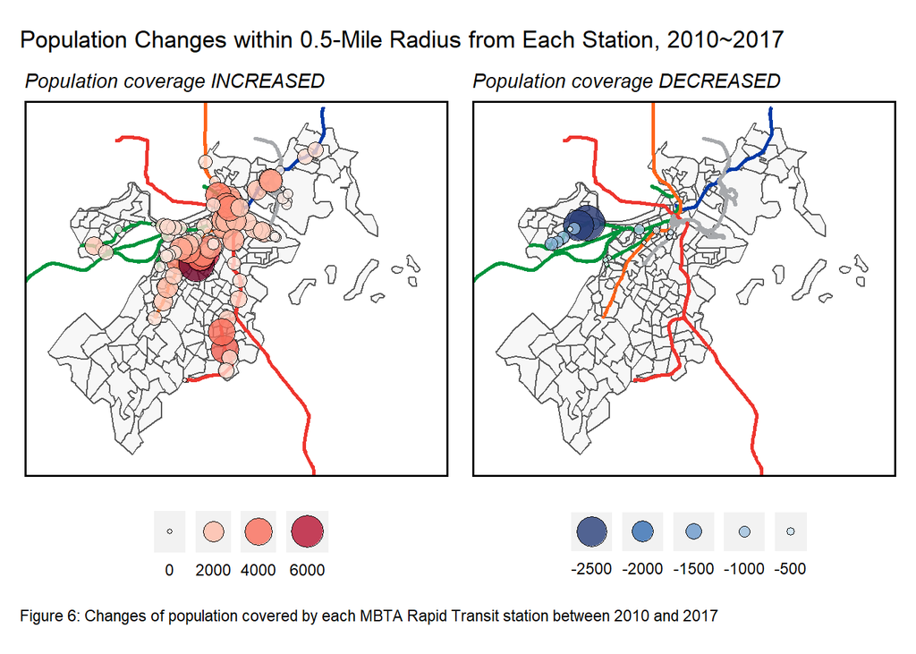

```r
# mapping code reference
# https://r-charts.com/spatial/proportional-symbol-map-ggplot2/
# graduated plot of population increase
pop_inc <-
  ggplot() +
  geom_sf(data = dat_17_acs5, fill = "#f7f7f7") +
  geom_sf(data = MBTA_Arcs, aes(colour = LINE), lwd = 1, show.legend = FALSE, size = 1) +
    scale_color_manual(values = c("#0039A6",      # blue
                                  "#00933C",      # green
                                  "#FF6319",      # orange
                                  "#EE352E",      # red
                                  "#A7A9AC")) +   # silver
  geom_sf(data = MBTA_Stops_pop_inc,
          pch = 21,
          aes(size = pop_change, fill = pop_change)) +
  scale_size(
    range = c(1, 9),
    guide = guide_legend(
      direction = "horizontal",
      nrow = 1,
      label.position = "bottom")) +
  scale_fill_gradientn(colours = hcl.colors(5, "Reds", rev = TRUE, alpha = 0.8)) +
  guides(fill = guide_legend(title = "")) +
  labs(subtitle = "Population coverage INCREASED",
       size = "") +
  coord_sf(xlim = c(738970, 813975), ylim = c(2907400, 2973900), crs = st_crs(dat_17_acs5)) +
  mapTheme() +
  theme(legend.position = "bottom")

# graduated plot of population decrease
pop_dec <-
  ggplot() +
  geom_sf(data = dat_17_acs5, fill = "#f7f7f7") +
  geom_sf(data = MBTA_Arcs, aes(colour = LINE), lwd = 1, show.legend = FALSE, size = 1) +
    scale_color_manual(values = c("#0039A6",      # blue
                                  "#00933C",      # green
                                  "#FF6319",      # orange
                                  "#EE352E",      # red
                                  "#A7A9AC")) +   # silver
  geom_sf(data = MBTA_Stops_pop_dec,
          pch = 21,
          aes(size = pop_change, fill = pop_change)) +
  scale_size(
    range = c(9, 1),
    guide = guide_legend(
      direction = "horizontal",
      nrow = 1,
      label.position = "bottom")) +
  scale_fill_gradientn(colours = hcl.colors(5, "Blues", rev = FALSE, alpha = 0.8)) +
  guides(fill = guide_legend(title = "")) +
  labs(subtitle = "Population coverage DECREASED",
       size = "") +
  coord_sf(xlim = c(738970, 813975), ylim = c(2907400, 2973900), crs = st_crs(dat_17_acs5)) +
  mapTheme() +
  theme(legend.position = "bottom")

# create a caption theme
capTheme <- theme(plot.caption = element_text(hjust=0))

# plot population pop_change in a row
pop_inc + pop_dec + plot_annotation(title = "Population Changes within 0.5-Mile Radius from Each Station, 2010~2017", caption = "Figure 6: Changes of population covered by each MBTA Rapid Transit station between 2010 and 2017", theme = capTheme)
```

```r
MBTA_Stops_pop_dec <- MBTA_Stops_pop_dec[order(MBTA_Stops_pop_dec$pop_change),]
table_dec <- MBTA_Stops_pop_dec %>%
  st_drop_geometry() %>%
  dplyr::select(STATION, LINE, pop_change) %>%
  head(5)

MBTA_Stops_pop_inc <- MBTA_Stops_pop_inc[order(MBTA_Stops_pop_inc$pop_change, decreasing = TRUE),]
table_inc <- MBTA_Stops_pop_inc %>%
  st_drop_geometry() %>%
  dplyr::select(STATION, LINE, pop_change) %>%
  head(5)

# display the tables side by side
# https://stackoverflow.com/questions/50277529/r-notebook-place-knitrkable-tables-side-by-side
knitr::kables(
  list(kable(caption = "Table 3a - 5 Stations with the greatest population increase", table_inc) %>% kable_styling("striped"),
  kable(caption = "Table 3b - 5 Stations with the greatest population decrease", table_dec) %>% kable_styling("striped"))
) %>% kable_styling()
```

Table 3a - 5 Stations with the greatest population increase

|  | STATION | LINE | pop_change |
| --- | --- | --- | --- |
| 38 | Nubian | SILVER | 7525 |
| 15 | Lenox St | SILVER | 5691 |
| 49 | Ashmont | RED | 4316 |
| 75 | Shawmut | RED | 3975 |
| 20 | Melnea Cass Blvd | SILVER | 3929 |

Table 3b - 5 Stations with the greatest population decrease

|  | STATION | LINE | pop_change |
| --- | --- | --- | --- |
| 2 | Packards Corner | GREEN | -2580 |
| 3 | Harvard Avenue | GREEN | -2517 |
| 8 | Chiswick Road | GREEN | -1220 |
| 6 | Washington Street | GREEN | -1113 |
| 4 | Griggs Street | GREEN | -1108 |

Although total population overall increased in Boston, such increase is not distributed evenly across the space. Figure 6 above shows changes of population covered by each station within a 0.5-mile radius between 2010 and 2017. While most of the stations increased their population coverage, there are station lost population coverage as well. Table 3a and 3b shows the top 5 stations which gained or lost the most population between the two years. Nubian station of the Silver Line gained more than 7,000 population coverage, while several Green Line stations located between Boston University and Boston College lost over 8,000 population in total. According to [Boston Planning & Development Agency](https://www.bostonplans.org/planning/planning-initiatives/plan-nubian-square#summary-goals), Nubian station is recognized as one of the busiest bus station in the city, and TOD is one of the main strategies used for economic development in that area. For the stations mentioned along the Green Line, the area is filled with relatively old apartments, and there is not much space for new development. In [an article by Kyle Paoletta](https://www.bostonmagazine.com/news/2019/09/10/harvard-allston/), the tension between local communities and private developers could be another important reason for the lack of development and lead to population loss over time.

### 5.3 Census Variables vs Distance from Each Station in Each Year

While Section 5.1 has compared the difference between TOD and non-TOD areas, it would be interesting to see how some of the selected variables perform differently further away from the TOD areas. In Figure 7 below, multiple buffers with different radius are created from each MBTA rapid transit station. With an increment of 0.5 mile, census tracts whose center points are covered by each buffer are selected, using the same methodology mentioned in Section 3. Average values of the select variables are then calculated between each distance interval, and variable vs distance plots are visualized in Figure 8 below.

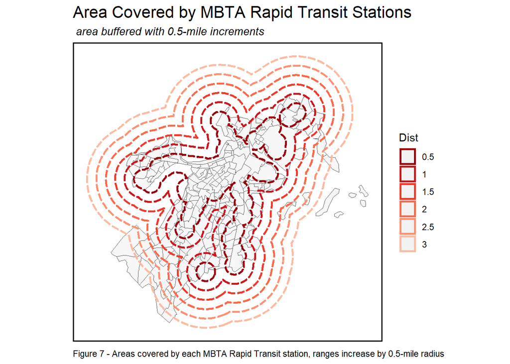

```r
# multiBuffer function
# the function generates buffers with 0.5-mile increments from stations
multiBuffer <- function(geom, d){
  tmpBuffer <- data.frame(matrix(nrow = 2*d, ncol = 2, dimnames = list(c(), c('geometry', 'Dist'))))
  for (i in seq(0.5, d, by = 0.5)){
    tmpBuffer[i*2, ] <- st_union(st_buffer(geom, 5280*i)) %>% st_sf() %>% mutate(Dist = i)
  }
  tmpBuffer$Dist <- as.factor(tmpBuffer$Dist)
  tmpBuffer <- tmpBuffer %>% st_as_sf() %>% st_set_crs(st_crs(geom))
  return(tmpBuffer)
}

# create the muilti buffer
buffers <- multiBuffer(MBTA_Stops, 3)

# plot the buffers
ggplot() +
  geom_sf(data = dat_17_acs5, fill = "#f7f7f7", lwd = 0.3) +
  geom_sf(data = buffers, aes(color = Dist), fill = NA, linetype = "41", lwd = 1) +
  scale_color_manual(values = brewer_pal(palette = 'Reds', direction = -1)(7)) +
  labs(title = "Area Covered by MBTA Rapid Transit Stations ",
       subtitle = " area buffered with 0.5-mile increments",
       caption = "Figure 7 - Areas covered by each MBTA Rapid Transit station, ranges increase by 0.5-mile radius") +
  mapTheme()
```

```r
# 2010 census tracts within each buffer
selectCentroids10 <- selectCentroids10 %>%
  dplyr::select(-Selection_Type) %>%
  mutate(BufferDist = 0.5)

rmGEOID <- c(selectCentroids10$GEOID)
for (i in 2:nrow(buffers)){
  tmpselectCentroids10 <-
    st_centroid(dat_10_acs5)[buffers[i,],] %>%
    filter(!(GEOID %in% rmGEOID)) %>%
    st_drop_geometry() %>%
    left_join(dplyr::select(dat_10_acs5, GEOID)) %>%
    st_sf() %>%
    dplyr::select(everything()) %>%
    mutate(BufferDist = i/2)
  selectCentroids10 <- rbind(selectCentroids10, tmpselectCentroids10)
  rmGEOID <- c(selectCentroids10$GEOID)
}

# 2017 census tracts within each buffer
selectCentroids17 <- selectCentroids17 %>%
  dplyr::select(-Selection_Type) %>%
  mutate(BufferDist = 0.5)

rmGEOID <- c(selectCentroids17$GEOID)
for (i in 2:nrow(buffers)){
  tmpselectCentroids17 <-
    st_centroid(dat_17_acs5)[buffers[i,],] %>%
    filter(!(GEOID %in% rmGEOID)) %>%
    st_drop_geometry() %>%
    left_join(dplyr::select(dat_17_acs5, GEOID)) %>%
    st_sf() %>%
    dplyr::select(everything()) %>%
    mutate(BufferDist = i/2)
  selectCentroids17 <- rbind(selectCentroids17, tmpselectCentroids17)
  rmGEOID <- c(selectCentroids17$GEOID)
}

# get mean values
sum10_byBuffer <- selectCentroids10 %>%
  na.omit() %>%
  st_drop_geometry() %>%
  dplyr::select(-GEOID, -year) %>%
  group_by(BufferDist) %>%
  summarise_at(vars(everything()), funs(mean))

sum17_byBuffer <- selectCentroids17 %>%
  na.omit() %>%
  st_drop_geometry() %>%
  dplyr::select(-GEOID, -year) %>%
  group_by(BufferDist) %>%
  summarise_at(vars(everything()), funs(mean))

# prepare a df for plotting
var10 <- sum10_byBuffer %>%
  dplyr::select(BufferDist, MedRent, MedIncome, pctYoungBach, pctRent) %>%
  mutate(pctYoungBach = pctYoungBach*100) %>%
  mutate(pctRent = pctRent*100) %>%
  mutate(year = "2010")

var17 <- sum17_byBuffer %>%
  dplyr::select(BufferDist, MedRent, MedIncome, pctYoungBach, pctRent) %>%
  mutate(pctYoungBach = pctYoungBach*100) %>%
  mutate(pctRent = pctRent*100) %>%
  mutate(year = "2017")

var1017 <- rbind(var10, var17)
```

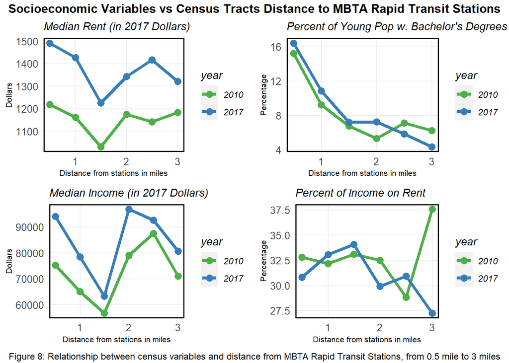

```r
# median rent
rent_plot <-
  ggplot(data = var1017, aes(x = BufferDist, y = MedRent, color = year)) +
  geom_line(lwd = 1.5)+
  geom_point(size = 3)+
  labs(subtitle = "Median Rent (in 2017 Dollars)",
       x = 'Distance from stations in miles',
       y = 'Dollars') +
  scale_color_manual(
    name = "year",
    values=brewer_pal(palette = "Set1", direction = -1)(3)) +
  plotTheme() +
  theme(axis.title.x = element_text(size = 8), axis.title.y = element_text(size = 8))

# median income
income_plot <-
  ggplot(data = var1017, aes(x = BufferDist, y = MedIncome, color = year)) +
  geom_line(lwd = 1.5)+
  geom_point(size = 3)+
  labs(subtitle = "Median Income (in 2017 Dollars)",
       x = 'Distance from stations in miles',
       y = 'Dollars') +
  scale_color_manual(
    name = "year",
    values = brewer_pal(palette = "Set1", direction = -1)(3)) +
  plotTheme() +
  theme(axis.title.x = element_text(size = 8), axis.title.y = element_text(size = 8))

# young professionals
young_plot <-
  ggplot(data = var1017, aes(x = BufferDist, y = pctYoungBach, color = year)) +
  geom_line(lwd = 1.5)+
  geom_point(size = 3)+
  labs(subtitle = "Percent of Young Pop w. Bachelor's Degrees",
       x = 'Distance from stations in miles',
       y = 'Percentage') +
  scale_color_manual(
    name = "year",
    values = brewer_pal(palette = "Set1", direction = -1)(3)) +
  plotTheme() +
  theme(axis.title.x = element_text(size = 8), axis.title.y = element_text(size = 8))

# pct of income over rent
rentIncome_plot <-
  ggplot(data = var1017, aes(x = BufferDist, y = pctRent, color = year)) +
  geom_line(lwd = 1.5)+
  geom_point(size = 3)+
  labs(subtitle = "Percent of Income on Rent",
       x = 'Distance from stations in miles',
       y = 'Percentage') +
  scale_color_manual(
    name = "year",
    values = brewer_pal(palette = "Set1", direction = -1)(3)) +
  plotTheme() +
  theme(axis.title.x = element_text(size = 8), axis.title.y = element_text(size = 8))

# plot in two by two arrangement
grid.arrange(rent_plot, young_plot, income_plot, rentIncome_plot,
             ncol = 2, nrow = 2,
             bottom = textGrob("Figure 8: Relationship between census variables and distance from MBTA Rapid Transit Stations, from 0.5 mile to 3 miles", gp=gpar(fontsize = 9)),
             top = textGrob("Socioeconomic Variables vs Census Tracts Distance to MBTA Rapid Transit Stations",
                            gp=gpar(fontsize = 12, fontface = 'bold')))
```

One common pattern observed from both the median rent and the median income plot is that there is a sudden drop at 1.5 miles away from stations. One possible reason is that such areas are too far for walking to a rapid transit station while not far enough to form suburban neighborhoods. Moreover, according to the [Imagine Boston 2030](https://www.boston.gov/sites/default/files/embed/file/2018-06/imagine20boston202030_pages2.pdf) plan, there are lots of industrial lands in between different neighborhoods in Boston, and those areas gradually become boundaries among different neighborhoods. Therefore, at 1.5 miles from rapid transit station, the industrial environment likely suppress the rent and made the areas less attractive to higher income population. In terms of the percentage of young professionals, the percentage drops as the distance increases. Therefore, creating better transit system and promoting mixed use developments near transit stations is a way to retain talented young workers in Boston.

## 6. Conclusion

TODs at MBTA rapid transit stations had successfully attracted young professionals from 2010 to 2017. Data in this study have proved TOD can be a practical approach for the city to retain its young talents. Strategies proposed in the [Imagine Boston 2030](https://www.boston.gov/sites/default/files/embed/file/2018-06/imagine20boston202030_pages2.pdf) plan had also taken gentrification prevention into consideration. TODs in Boston, therefore, should be carefully carried out by balancing attractiveness brought by mixed use developments and rent burdens came with the benefits.

## 7. Sources

Data Sources:

1. 2006-2010, 2013-2017 5-year ACS. US Census Bureau
2. MBTA Rapid Transit GIS Data. MassGIS. [URL](https://www.mass.gov/info-details/massgis-data-mbta-rapid-transit).
3. Boundary of the city of Boston, City of Boston. [URL](https://data.boston.gov/dataset/city-of-boston-boundary/resource/53e1ef88-950e-4b91-8b2a-f05f2e025f69?inner_span=True).

References:

1. *Imaging Boston 2030*. City of Boston. [URL](https://www.boston.gov/sites/default/files/embed/file/2018-06/imagine20boston202030_pages2.pdf).
2. *Smart Growth / Smart Energy Toolkit Modules - Transit Oriented Development (TOD)*. Executive Office of Energy and Environmental Affairs, Mass.gov. [URL](https://www.mass.gov/service-details/smart-growth-smart-energy-toolkit-modules-transit-oriented-development-tod#:~:text=TOD%20occurs%20within%20one%2Dquarter,Copley%20Place%20in%20Boston).
3. US Inflation Calculator. [URL](https://www.usinflationcalculator.com/).
4. *PLAN: Nubian Square*. Boston Planning & Development Agency. [URL](https://www.bostonplans.org/planning/planning-initiatives/plan-nubian-square#summary-goals).
5. *Is Harvard Destroying Allston - or Saving it?*. Kyle Paoletta. City Life. [URL](https://www.bostonmagazine.com/news/2019/09/10/harvard-allston/).